# PersonalFitnessActivityQualityPrediction

AP

Saturday, May 23, 2015

## Summary

The goal of this project is to predict the quality of quality of exercise for a subject using a set of measurements related to the personal fitness activity performed. The training dataset consists of 19622 observations of 160 variables from 6 subjects. The response variable is ‘classe’ which can take 5 different values - A, B, C, D, E. We first identified the covariates that did not seem to have to effect on the response variable and created a new training set with just 53 variables. The final model that gave the best prediction results was a Random Forest model.

## Data Processing

Information about the data set, the purpose of the experiment and lots of other detals is available from the website here: http://groupware.les.inf.puc-rio.br/har (see the section on the Weight Lifting Exercise Dataset).

Load required libraries and read tarining and test data

```r
library(caret)
trainAll = read.csv("pml-training.csv", stringsAsFactors=FALSE)
testAll = read.csv("pml-testing.csv", stringsAsFactors=FALSE)
```

Data Cleaning

1. Lot of columns have NA or blank values. Remove these as they will not have a significant impact on the response variable.
2. Also remove the first 7 columns which are just identifier and book-keeping columns
3. Remove problem_id from test set as it does not exist in the training set
4. Convert the response variable classe to a factor

```r
cleanData <- function(data, thresh) {
  newData = data
  newData = data[, colSums(is.na(data)) < thresh]   #Remove the columns where number of NAs is greater than thresh
  newData = newData[, colSums(newData=="") < thresh] #Remove the columns where number of blank values is greater than thresh
  newData = newData[, -c(1:7)]

  newData;
}

trainCleaned = cleanData(trainAll, nrow(trainAll) * 0.95) # Remove columns where 95% of the values are NA or blank
test = cleanData(testAll, nrow(testAll) * 0.95) # Remove columns where 95% of the values are NA or blank
test$problem_id= NULL #Remove problem_id from test set as it is not present on the training set

trainCleaned$classe = as.factor(trainCleaned$classe) #Convert classe to a factor
```

The resulting dataframe now has 53 columns Check if there are any more near zero variance predictors that can be removed. None found, so we are good to go

```r
nearZeroVar(trainCleaned, saveMetrics=TRUE)
```

[output not shown]

Split the data into training and validation data sets (60-40 split).

```r
inTrain = createDataPartition(trainCleaned$classe, p=0.6, list=FALSE)
training = trainCleaned[inTrain,]
validation = trainCleaned[-inTrain,]
```

# Model Building

First lets try the Linear Discriminant Analysis(lda) method of classification

```r
set.seed(1234)
model_lda = train(classe ~ ., data=training, method="lda")
model_lda$results
```

```
##   parameter  Accuracy     Kappa  AccuracySD     KappaSD
## 1      none 0.6975612 0.6172422 0.006831693 0.008622445
```

Accuracy for the lda model is 0.698 which is pretty low.

Now lets try the rpart model

```r
set.seed(1234)
model_rpart = train(classe ~ ., data=training, method="rpart")
model_rpart$results
```

```
##           cp  Accuracy      Kappa AccuracySD    KappaSD
## 1 0.03239203 0.5143656 0.36970645 0.04147836 0.06624307
## 2 0.06007752 0.4174875 0.21164524 0.06449059 0.10645479
## 3 0.11699098 0.3295331 0.07000727 0.04215270 0.06346025
```

Accuracy for the rpart model is even worse - 0.514

Now lets try Random Forest. Use 10 fold cross-validation

```r
set.seed(54321)
fitControl = trainControl(method="cv", number=10)
model_rf <- train(classe ~ ., data=training, method="rf", trControl=fitControl)
```

```r
model_rf$results
```

```
##   mtry  Accuracy     Kappa  AccuracySD     KappaSD
## 1    2 0.9897251 0.9869993 0.003970552 0.005025599
## 2   27 0.9905744 0.9880755 0.003110601 0.003937088
## 3   52 0.9856498 0.9818428 0.004954459 0.006273977
```

```r
model_rf$finalModel
```

```
##
## Call:
##  randomForest(x = x, y = y, mtry = param$mtry)
##                Type of random forest: classification
##                      Number of trees: 500
## No. of variables tried at each split: 27
##
##         OOB estimate of  error rate: 0.81%
## Confusion matrix:
##      A    B    C    D    E class.error
## A 3339    5    3    0    1 0.002688172
## B   19 2252    8    0    0 0.011847301
## C    0   11 2036    7    0 0.008763389
## D    0    3   23 1901    3 0.015025907
## E    0    1    6    5 2153 0.005542725
```

Accuracy for the Random Forest model is excellent - 0.991 The expected OOB estimate of error rate is 0.81%

Let’s take a look at some more results to make sure the model is good. Plot the error curve.Also draw a plot to show the importance of various covariates

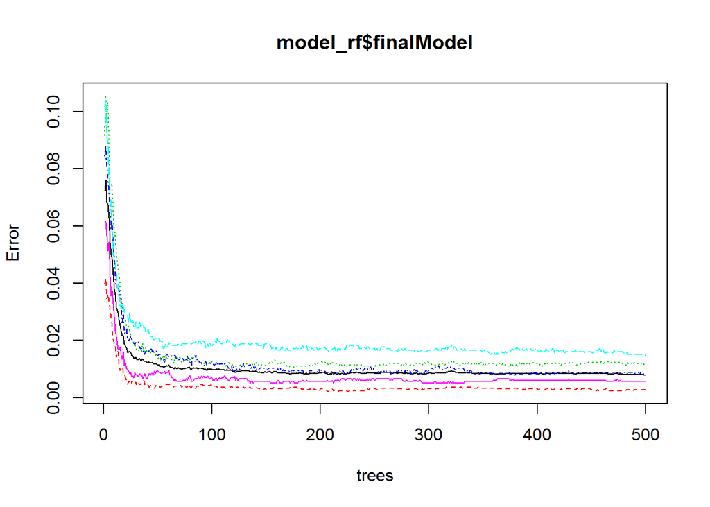

```r
plot(model_rf$finalModel)
```

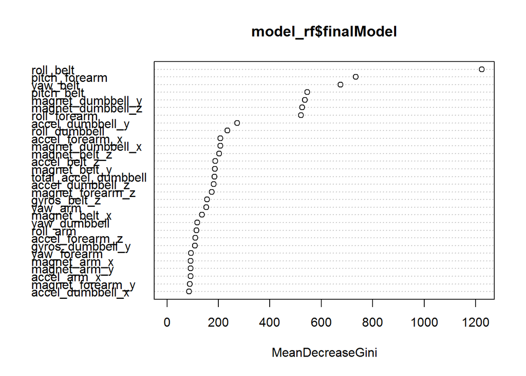

```r
varImpPlot(model_rf$finalModel)
```

Predict for validation set

```r
predicted_rf = predict(model_rf, validation)
confusionMatrix(predicted_rf, validation$classe)
```

```
## Confusion Matrix and Statistics
##
##           Reference
## Prediction    A    B    C    D    E
##          A 2227   17    0    0    0
##          B    5 1494   12    1    1
##          C    0    7 1352   10    1
##          D    0    0    4 1274    2
##          E    0    0    0    1 1438
##
## Overall Statistics
##
##                Accuracy : 0.9922
##                  95% CI : (0.99, 0.994)
##     No Information Rate : 0.2845
##     P-Value [Acc > NIR] : < 2.2e-16
##
##                   Kappa : 0.9902
##  Mcnemar's Test P-Value : NA
##
## Statistics by Class:
##
##                      Class: A Class: B Class: C Class: D Class: E
## Sensitivity            0.9978   0.9842   0.9883   0.9907   0.9972
## Specificity            0.9970   0.9970   0.9972   0.9991   0.9998
## Pos Pred Value         0.9924   0.9874   0.9869   0.9953   0.9993
## Neg Pred Value         0.9991   0.9962   0.9975   0.9982   0.9994
## Prevalence             0.2845   0.1935   0.1744   0.1639   0.1838
## Detection Rate         0.2838   0.1904   0.1723   0.1624   0.1833
## Detection Prevalence   0.2860   0.1928   0.1746   0.1631   0.1834
## Balanced Accuracy      0.9974   0.9906   0.9928   0.9949   0.9985
```

Accuracy for prediction is 0.9922 which is very close to the accuracy over the training set.

# Results

Predict for the test set

```r
predicted_test = predict(model_rf, test)
predicted_test
```

```
##  [1] B A B A A E D B A A B C B A E E A B B B
## Levels: A B C D E
```

The final submission was 100% correct, proving the accuracy of the final model.